# Linear Regression - California

Debartha Paul

2023-05-20

## Introduction

We’ll be doing a Linear Regression for the California Dataset available at [Kaggle](https://www.kaggle.com/datasets/camnugent/california-housing-prices).

## Loading and cleaning data

We first load the dataset:

```r
california <- read.csv("housing.csv")
names(california)
```

```
 [1] "longitude"          "latitude"           "housing_median_age"
 [4] "total_rooms"        "total_bedrooms"     "population"
 [7] "households"         "median_income"      "median_house_value"
[10] "ocean_proximity"
```

```r
dim(california)
```

```
[1] 20640    10
```

```r
summary(california)
```

```
   longitude         latitude     housing_median_age  total_rooms
 Min.   :-124.3   Min.   :32.54   Min.   : 1.00      Min.   :    2
 1st Qu.:-121.8   1st Qu.:33.93   1st Qu.:18.00      1st Qu.: 1448
 Median :-118.5   Median :34.26   Median :29.00      Median : 2127
 Mean   :-119.6   Mean   :35.63   Mean   :28.64      Mean   : 2636
 3rd Qu.:-118.0   3rd Qu.:37.71   3rd Qu.:37.00      3rd Qu.: 3148
 Max.   :-114.3   Max.   :41.95   Max.   :52.00      Max.   :39320

 total_bedrooms     population      households     median_income
 Min.   :   1.0   Min.   :    3   Min.   :   1.0   Min.   : 0.4999
 1st Qu.: 296.0   1st Qu.:  787   1st Qu.: 280.0   1st Qu.: 2.5634
 Median : 435.0   Median : 1166   Median : 409.0   Median : 3.5348
 Mean   : 537.9   Mean   : 1425   Mean   : 499.5   Mean   : 3.8707
 3rd Qu.: 647.0   3rd Qu.: 1725   3rd Qu.: 605.0   3rd Qu.: 4.7432
 Max.   :6445.0   Max.   :35682   Max.   :6082.0   Max.   :15.0001
 NA's   :207
 median_house_value ocean_proximity
 Min.   : 14999     Length:20640
 1st Qu.:119600     Class :character
 Median :179700     Mode  :character
 Mean   :206856
 3rd Qu.:264725
 Max.   :500001
```

We note that the dataset contains `207` missing values. As this is an insignificant amount of data with respect to the whole set, we may omit those observations.

```r
california <- na.omit(california)
california$ocean_proximity <- as.factor(california$ocean_proximity)
```

We also briefly view the contents of the dataset:

```r
head(california)
```

```
  longitude latitude housing_median_age total_rooms total_bedrooms population
1   -122.23    37.88                 41         880            129        322
2   -122.22    37.86                 21        7099           1106       2401
3   -122.24    37.85                 52        1467            190        496
4   -122.25    37.85                 52        1274            235        558
5   -122.25    37.85                 52        1627            280        565
6   -122.25    37.85                 52         919            213        413
  households median_income median_house_value ocean_proximity
1        126        8.3252             452600        NEAR BAY
2       1138        8.3014             358500        NEAR BAY
3        177        7.2574             352100        NEAR BAY
4        219        5.6431             341300        NEAR BAY
5        259        3.8462             342200        NEAR BAY
6        193        4.0368             269700        NEAR BAY
```

## Building Linear Model

Our variable of interest is the `median_house_value` variable, which contains the median of house values based on various factors.

Now we check for any multicollinearity in the dataset:

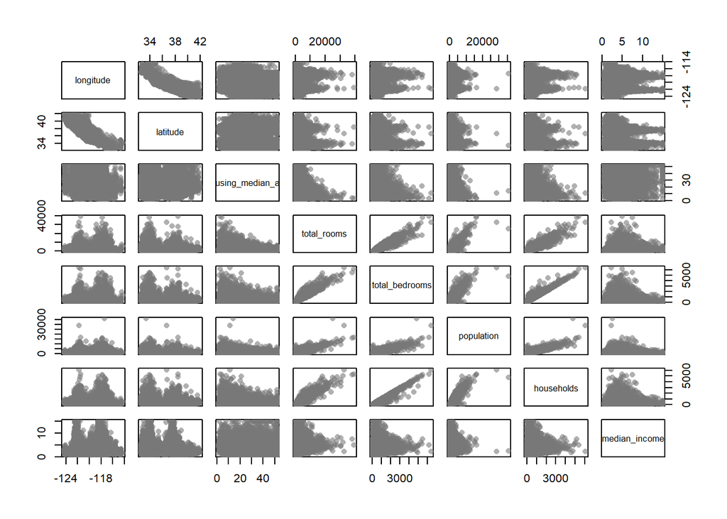

```r
pairs(california[, c(-9, -10)],
      pch = 16,
      col = rgb(120, 120, 120, maxColorValue = 255, alpha = 150))
```

This helps us to decrease the number of covariates in our linear regression model, which further results in drastically reducing the time complexity of our program. We note that `latitude` and `longitude` are highly collinear with each other, so it is redundant to keep both of them in our model. Further, we note that the `total_rooms`, `total_bedrooms`, `population` and `households` are almost perfectly multicollinear. Hence, we keep any one of them, and drop the other three. For simplicity, we choose `latitude` and `population` from the above and continue our model.

Thus, our linear regression model now looks like the following:
$$y =
\beta_0+\beta_1x_1+\beta_2x_2+\beta_3x_3+\beta_4x_4+\beta_5x_5$$
where:

- $\beta_0$ is the average value of the house when all the other covariates are `0`
- $\beta_1$ is the coefficient corresponding to `latitude`
- $\beta_2$ is the coefficient corresponding to `housing_median_age`
- $\beta_3$ is the coefficient corresponding to `population`
- $\beta_4$ is the coefficient corresponding to `median_income`
- $\beta_5$ is the coefficient corresponding to the factor variable `ocean_proximity`

The function for the linear model in `R` is `lm`. We use this to build our model for the linear regression. However, before doing that, we would like to break our data into training and test sets. We would do a random sampling, after setting a fixed seed for reproducibility and the ratio for train to test is 80:20.

```r
set.seed(2023)
x <- sample(1:nrow(california),
            0.8 * nrow(california))
train <- california[x,]
test <- california[-x,]
```

We now proceed to build the model with the training set:

```r
model <- lm(median_house_value ~ latitude + housing_median_age + population + median_income + ocean_proximity,
            data = train)
summary(model)
```

```
Call:
lm(formula = median_house_value ~ latitude + housing_median_age +
    population + median_income + ocean_proximity, data = train)

Residuals:
    Min      1Q  Median      3Q     Max
-546666  -46185  -12466   30421  417994

Coefficients:
                            Estimate Std. Error t value Pr(>|t|)
(Intercept)                5.020e+04  1.181e+04   4.251 2.14e-05 ***
latitude                  -2.797e+01  3.295e+02  -0.085    0.932
housing_median_age         9.691e+02  5.124e+01  18.914  < 2e-16 ***
population                -7.275e-02  5.318e-01  -0.137    0.891
median_income              3.856e+04  3.176e+02 121.398  < 2e-16 ***
ocean_proximityINLAND     -7.139e+04  1.582e+03 -45.117  < 2e-16 ***
ocean_proximityISLAND      1.843e+05  3.278e+04   5.622 1.92e-08 ***
ocean_proximityNEAR BAY    1.287e+04  2.232e+03   5.767 8.20e-09 ***
ocean_proximityNEAR OCEAN  1.666e+04  1.813e+03   9.185  < 2e-16 ***
---
Signif. codes:  0 '***' 0.001 '**' 0.01 '*' 0.05 '.' 0.1 ' ' 1

Residual standard error: 73250 on 16337 degrees of freedom
Multiple R-squared:  0.5999,    Adjusted R-squared:  0.5997
F-statistic:  3062 on 8 and 16337 DF,  p-value: < 2.2e-16
```

## Prediction

```r
pred <- predict(model,
                newdata = data.frame(latitude=test$latitude,
                                     housing_median_age=test$housing_median_age,
                                     population=test$population,
                                     median_income=test$median_income,
                                     ocean_proximity=test$ocean_proximity)
)
head(pred)
```

```
       1        2        3        4        5        6
232634.9 254632.1 230903.7 194118.8 212744.6 150770.7
```

That ends the discussion for Linear regression on the California Dataset.